# Counterfactual Model Building

```r
library(causaldemon, quietly = T, warn.conflicts = F)
```

My goal is to create a Bayes net and an equivalent structural causal model in Pyro and compare their performance on intervention/counterfactual prediction using the Sachs network

My goal with this vignette was to quickly fit some parameters on the network, as I want to focus on the prediction task, not parameter inference.

I want to fit these parameters on the Sachs network using all the intervention data. I did this first by converting the processed discrete data into 2 levels (“on” and “off”) instead of 3, since that is more interpretable and has less parameters to deal with. I also tried working with the continuous unprocessed data, applying an inverse hyperbolic transform, and fitting each node with a linear model that includes its parents, and a bunch of interaction effects that should account both for interventions and batch effects. My conclusion is that this is less preferable than working with the discrete processed data because (1) explaining the transform to a non-bio audience would be challenging, (2) it seems to call for latent variables on top of noise variables in a way that makes me want to use Stan, (3) it discrete model seems to capture strange interactions between parents like AND-gates that the linear model can’t, and (4) the discrete model lets me use if-then control flow, which I think is nice in the probabilistic programming setting. The estimates from the discrete model were used to build a Python notebook that I plan to submit to the Pyro repo.

Visualizing the network.

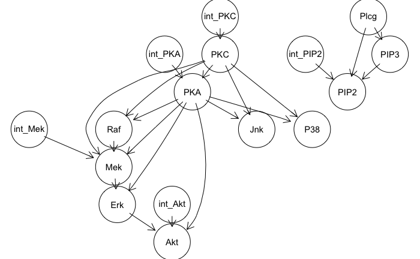

Let’s first fit a binary network, and get an idea of what the prediction task will be.

Further, the counterfactual prediction task will becompared against the Mek intervention data. So let’s bias the parameter inference strongly in favor of that subset. This is kind of a hack to deal with bias in parameter inference, as the goal of this analysis is not parameter inference.

```r
training <- rbind(set_1, sample_n(set_2, size = nrow(set_1)*3, replace = TRUE))
```

[output not shown]

Create a network without interventions, and fit it using simulated data from the intervention network.

```r
param_fit <- int_net %>%
  bn.fit(training, method = "bayes") %>%
  rbn(100000) %>%
  select(-int_PKA, -int_Akt, -int_PKC, -int_PIP2, -int_Mek) %>%
  as.data.frame %>%
  {bn.fit(net, ., method = "bayes")}
```

[output not shown]

Some observations on the distributions.

```r
fit1$Akt
```

```
  Parameters of node Akt (multinomial distribution)

Conditional probability table:

, , PKA = off

     Erk
Akt         off        on
  off 0.6942094 0.1927065
  on  0.3057906 0.8072935

, , PKA = on

     Erk
Akt         off        on
  off 0.6844884 0.6723091
  on  0.3155116 0.3276909
```

When PKA is off, if Erk is off, Akt is likely off, and when Erk is on, Akt is likely on. When PKA is on, Erk seems to have little effect on Akt. In Python could code it up as follows:

[output not shown]

The other proteins are similar. Mek is a bit more complicated.

```r
fit1$Mek
```

[output not shown]

```r
print(fit1$Plcg)
print(fit1$PIP2)
print(fit1$PIP3)
```

```r
.data <- training %>%
  mutate(
    Raf = as.factor(ifelse(Raf == 1, 'off', 'on')),
    Mek = as.factor(ifelse(Mek == 1, 'off', 'on')),
    Plcg = as.factor(ifelse(Plcg == 3, 'on', 'off')),
    PIP2 = as.factor(ifelse(PIP2 == 3, 'on', 'off')),
    PIP3 = as.factor(ifelse(PIP3 == 3, 'on', 'off')),
    Erk = as.factor(ifelse(Erk == 1, 'off', 'on')),
    Akt = as.factor(ifelse(Akt == 1, 'off', 'on')),
    PKA = as.factor(ifelse(PKA == 1, 'off', 'on')),
    PKC = as.factor(ifelse(PKC == 1, 'off', 'on')),
    P38 = as.factor(ifelse(P38 == 1, 'off', 'on')),
    Jnk = as.factor(ifelse(Jnk == 1, 'off', 'on'))
  ) %>%
  mutate(
    int_PKA = as.factor(as.integer(INT == 'PKA')),
    int_Akt = as.factor(as.integer(INT == 'Akt')),
    int_PKC = as.factor(as.integer(INT == 'PKC')),
    int_PIP2 = as.factor(as.integer(INT == 'PIP2')),
    int_Mek = as.factor(as.integer(INT == 'Mek'))
  ) %>%
  as.data.frame

val_str <- paste0(
  "[Plcg]",
  "[PIP3|Plcg]",
  "[PKC]",
  "[PKA|PKC]",
  "[Raf|PKC:PKA]",
  "[Mek|PKC:PKA:Raf]",
  "[Erk|Mek:PKA]",
  "[Akt|Erk:PKA]",
  "[P38|PKC:PKA]",
  "[Jnk|PKC:PKA]",
  "[PIP2|Plcg:PIP3]"
)

net <- model2network(val_str)

fit2 <- int_net %>%
  bn.fit(training, method = "bayes") %>%
  rbn(100000) %>%
  select(-int_PKA, -int_Akt, -int_PKC, -int_PIP2, -int_Mek) %>%
  as.data.frame %>%
  {bn.fit(net, ., method = "bayes")}
```

```r
print(fit1$Plcg)
print(fit2$Plcg)
```

```r
print(fit1$PIP2)
print(fit2$PIP2)
```

# Predicting Interventions

This is an attempt to do evaluation by calculating log-likelihood of test data. I wrote one using `cpquery`, and one that directly calculates the logmass using the CPDs.

```r
results <- list()
INT_test <- interventions[!training_selection]

for(i in 1:nrow(test)){
  if(INT_test[i] != "observational"){
    int_target <- INT_test[i]
    evidence <- structure(list(test[[prot]][i]), names=prot)
    int_fit <- mutilated(fit1, evidence)
    ordered_nodes <- node.ordering(fit1)
    factors <- NULL
    for(prot in ordered_nodes){
      parents <- bnlearn::parents(int_fit, prot)
      prot_cpd <- as_tibble(int_fit[[prot]]$prob)
      if(nrow(prot_cpd) == 2){
        names(prot_cpd)[1] <- prot
      }
      obs <- test[i, c(prot, parents)]
      str <- paste0(names(obs), " == '",
                    map(obs, as.character), "'",
                    sep = "", collapse = " , ")
      cmd <- paste0('filter(prot_cpd, ', str, ")$n")
      factor <- eval(parse(text = cmd))
      factors <- c(factors, factor)
    }
    names(factors) <- ordered_nodes
    results[[int_target]] <- c(results[[int_target]], factors)
  }
}


for(i in 1:nrow(test)){
  if(INT_test[i] != "observational"){
    prot <- INT_test[i]
    evidence <- structure(list(test[[prot]][i]), names=prot)
    int_fit <- mutilated(fit1, evidence)
    not_prot <- setdiff(names(test), prot)
    obs <- paste("(", not_prot, " == '",
            sapply(test[1, not_prot], as.character), "')",
            sep = "", collapse = " & ")
    ev <- paste0("(", names(evidence), " == '", evidence[[prot]], "')")
    cmd <- paste0("log(cpquery(int_fit, ", obs, ", ", ev, "))", sep = "")
    results[[prot]] <- c(results[[prot]], eval(parse(text = cmd)))
  }
}
```

Thinking further, I think it is preferable to focus on a specific prediction task. I think Erk is a good candidate because it is downstream of many of the interventions.

Let’s see if there is an intervention dataset for Erk where we have a great difference from the others.

```r
plot_comparison <- function(int){
  int_erk <- filter(test, INT_test == int)$Erk
  not_int_erk <- filter(test, INT_test != int)$Erk
  title <- paste0('Erk in ', int, ' and non-', int, ' sets.')
  barplot(prop.table(table(not_int_erk)), ylim=c(0,1), col=alpha("darkgrey", .5), main=title)
  barplot(prop.table(table(int_erk)), ylim=c(0,1), add=T, col=alpha("darkred", .5))
}
plot_comparison('PKA')
plot_comparison('Akt')
plot_comparison('PKC')
plot_comparison('PIP2')
plot_comparison('Mek')
```

[output not shown]

# Parameter estimation for a linear SCM

We will fit a linear model to the protein values transformed by the inverse hyperbolic transform, which is like the log transform but allowing for 0’s.

```r
.data <- tcells$raw_data

asinh <- function(x) {
  log(x + sqrt(x*x + 1))
}

prot_names <- c("Raf", "Mek", "Plcg", "PIP2", "PIP3", "Erk", "Akt", "PKA", "PKC", "P38", "Jnk")

for (prot in prot_names){
  .data[prot] <- asinh(.data[prot])
}
```

Create a variable for the batch of the data. Each protein variable will have this as a predictor in order to estimate batch effects.

```r
for(i in 1:length(.raw_data)){
  .data[[i]]$batch <- names(.data)[i]
}
```

Next, we create the model for each protein. We want a linear model that is additive in the parents, so we exclude multiplicative effects between parents. However, to account for pertubations and batch effects, we include a multiplicative effect between batch and each parent.

```r
formulas <- list(
  PKC = PKC ~ batch,
  PKA = PKA ~ PKC*batch,
  Jnk = Jnk ~ PKC*batch + PKA*batch,
  Raf = Raf ~ PKC*batch + PKA*batch,
  Mek = Mek ~ PKC*batch + PKA*batch + Raf*batch,
  Erk = Erk ~ Mek*batch + PKA*batch,
  Akt = Akt ~ Erk*batch + PKA*batch,
  P38 = P38 ~ PKA*batch + PKC*batch,
  Plcg = Plcg ~ batch,
  PIP3 = PIP3 ~ Plcg*batch,
  PIP2 = PIP2 ~ PIP3*batch + Plcg*batch
)
```

Seperate the data into training and test sets.

```r
training_selection <- sample(c(T, F), prob = c(.9, .1), size = nrow(.fit_data), replace=T)
training <- .fit_data[training_selection, ]
test <- .fit_data[!training_selection, ]
```

Fit a model for each protein.

```r
fit_protein <- function(prot){
  fit <- lm(formulas[[prot]], training)
  res <- predict.glm(fit, newdata = test, type = "response") - test[[prot]]
  mse <- mean(res**2)
  return(list(fit=tidy(fit), sqrd_errs = summary(res)))
}

model <- map(prot_names, fit_protein)
names(model) <- prot_names
```

There might be something that can be done here to improve residuals. IRLS?